# notes_2016_07_31_creative_facebook

《打造Facebook》 读书总结

## 本书作者

王淮（Harry），线性资本创始合伙人，毕业于斯坦福大学和浙江大学。Facebook第二位中国籍工程师，第一位中国籍研发经理。最初进入Facebook时任工程师，后转为管理者，一手开创了Facebook的支付安全和客服工具领域。2011年离开Facebook后，回国做天使投资人。

## 写在前面

这是一本好书，作者牛逼的经历、总结在两百页文字中娓娓道来，让那些没有机会见证互联网传奇发生过程的人了解那些故事。读罢此书，难以释手，一定要花些时间总结总结，这既是对本书内容的提炼，也加上我个人的一些观点。这个读书报告分成三部分：

# 1/3 一个渴望改变世界的人 - Mark Zuckerberg

- 塑造一流的文化
- 个人成长

# 2/3 黑客创办的公司

- 开发新产品
- 新兵训练营
- Hackathon

# 3/3 创新精神

- 要勇于尝试破坏性创新
- 创新型领导

# 一个渴望改变世界的人

创始人团队决定着创业公司的发展，从19岁开始，Mark就一直作为Facebook的CEO，从一个在大学和高中流行的社交网络走到世界上最大的社交网络，他有着最快的学习速度，领导者一个地球上最有智慧的一群人。Facebook并不是第一个做社交网络的，为什么它打败了其它对手？我觉得有下面重要的原因:

① 生活在温馨的家庭，不缺乏爱和陪伴

② 出生在1984年

③ 进入哈佛大学

Mark是一个比较容易害羞的人，这种内向的性格和家里有一个姐姐两个妹妹有关系吧，而这样Mark就变得比较擅于倾听，在创业的过程中，Mark的大学老师也成为了他的左膀右臂，因为大家喜欢和他在一起。1984年有很多事件，对个人电脑发展影响深远，同时也是黑客文化开始形成的时候。看过《异类》的朋友可能更认同，这个“时机”是多么重要。进入哈佛，就融入到了一个高度发达的圈子，这些人根本就不用上大学，或者老师，他们就是为了能找到同类而上大学的。

## 塑造一流的企业文化

互联网公司是需要集体智慧的，这个和冷兵器时代，各种军团采用“愚军”的策略不同，互联网时代下，信息流动快，组织要想胜出，就要依靠高度开放的机制。

Facebook通过一个宏大和共同的愿景，一定的纪律约束，及时、高效、透明的信息流通，合理的利益分配机制和高度的公众曝光，建立了一个精英组织。Facebook有很多办法来让这一切执行下去，并且不会妥协：

① 只招聘最优秀的人

② 双向汇报机制

③ 不断的学习和再创造

因为优秀的人只喜欢和优秀的人合作，所以，Facebook会从美国重点的20所高校中寻找人才，而大部分的员工来自于麻省理工、斯坦福和卡内基梅隆。公司的营收等业务数据，一开始也是全公司公开的，扎克伯格还会在每周五下午5～6点回答员工的任何提问，只要有兴趣，任何员工都可以参与，远程的同事可以视频接入。

Facebook是一家科技驱动的公司，黑客文化是Facebook的核心理念，在上市前夕，扎克伯格用大量的篇幅解释“Hacker Way”:

The word “hacker” has an unfairly negative connotation from being portrayed in the media as people who break into computers. In reality, hacking just means building something quickly or testing the boundaries of what can be done. Like most things, it can be used for good or bad, but the vast majority of hackers I’ve met tend to be idealistic people who want to have a positive impact on the world.

最后，这个是一个值得托付终生的组织，大量的员工赚了一辈子花不完的钱，还要委托给基金打理留给下一代。

## 个人成长

Facebook是一个注重个体发展的公司，从入职后进入新兵训练营，到Mentor机制，再到Hack a month，都是帮助个体寻找实现自身价值的途径。它是一个多元化的公司，有着足够的容忍度去接纳错误。

if you never down the site, you are not a facebook engineer.

① 新兵训练营

在入职后的前六个星期，工程师并不会被指定到指定的工作岗位上，而是带有很大选择性的去加入不同项目小组，有导师带领着熟悉公司的文化、产品和方法，然后再确定一个最适合的团队和项目。

② Mentor机制

Mentor对Mentee是有责任的，这种责任涵盖在工作生活中各方面的意见交换，最常见的是两个星期一起吃一次午餐，好好聊聊最近的状态。

③ Hack a month

如果在一个项目，产品上工作太久了，就会觉得每天重复，工作变得无聊，Facebook的Hack a month机制允许员工在一个月内重新在公司内部寻找自己的热情的所在，在这个月内，可以到一个新团队做事情，最后在新旧团队负责人的同意后，就将人事关系调整到新团队。

很多从Facebook离开的人，选择离职创业，一方面是自己的经济负担没有了，一方面是寻找新的人生方向。而Facebook就像一个培训机构一样，将大家感召到一起，给予每个人最好的平台去展示自己，然后去更大的舞台。

# 2/3 黑客创办的公司

## 开发新产品

以下是Facebook启动新产品／功能时的流程：

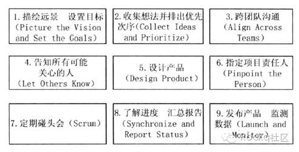

### 描绘愿景 设置目标

描述愿景就是在脑子里想清楚这个功能的使用过程和体验，就是它完成之后的样子，设定目标在Facebook有一种常用的方法 － SMART方法：

1. Specific - 非常详细具体的
2. Measurable - 能够衡量的
3. Aggressive - 有难度，有挑战性的
4. Realistic - 现实的
5. Time-bound - 在时限范围内的

### 搜集想法并排出优先次序

[figure not shown]

根据每个想法对目标的影响和其所需的资源进行讨论，这些会议通常是技术经理或者产品经理来主导，但要求每个人积极的参与，发表意见。关于时间的分配，还有一个“6-2-2”原则：60%的时间放到那些能够预期的工作上，20%的时间花在后台架构和产品质量上，20%的时间花在比较有风险、有争议、可能会带来颠覆性后果的那些想法上。

### 跨团队沟通

一类是不同职能之间的沟通，另一类是相关兄弟组之间的沟通。跨团队沟通最关键的就是让不同组的同事知道自己的任务和角色。

### 告诉所有可能关心的人

在跨团队沟通之后，要召开一次最终计划的定夺会，主要是工程师和产品经理等一些非常相关的人参与，如果前面几项做的好，这个会议也就是半个小时。整个计划定出来，会有邮件发到所有的人，包括一线老板和二线老板，让他们清楚、理解并支持计划。

### 设计产品

具体执行中，都涉及四个维度：Feature Set, Time to Market, Budget, Quality.

设计产品的理念包括：不要过度设计，产品越简单越好，对于自己做出来的产品你必须是它的用户，产品要确实有用，不追求完美，保留最基本的质量底线。

### 指定项目责任人

对于每一个项目，都要指定一个明确的责任人，一般都是工程师。

### 定期碰头会

根据项目的紧张程度，可以是每天，也可以是每周一两次，一般每次在10-30分钟。

### 了解进度 汇总报告

编写简报应该注意：1. 应该能在1分钟内被人阅读完毕 2. 在开头一段，列出这周核心数据的变化 3. 应该只涉及组里的3-5个项目

### 发布产品 监测数据

使用灰度发布机制，最开始只让1％的用户使用该功能，如果没有什么问题，就再扩大到5%，10%，50%，90%，100%。

需要监测两类数据：一类反映系统当前的状态，比如访问量，访问速度；另外一类就是新功能的用户影响，比如点击率。

## 新兵训练营

新兵训练营是为了让新工程师们认识公司里面相关的人，在入职后的六个星期了解公司的文化、技术与产品，从而能迅速的融入Facebook，并能找到适合自身能力的兴趣小组。

Facebook希望工程师第一天就把所有的编程环境设置好，在第一天就提交代码，然后在周二参加每周例行的代码发布活动。Facebook相信，让工程师融入公司最好的办法就是通过代码进行交流。

在新兵训练营，每个新人有导师带领，导师要对公司有比较强的认识，一般要在公司待一年以上，而且是对从事人员管理岗位感兴趣的人。导师会花1/4的正常工作时间，解决新员工提出的任何问题，进行每周一次的“一对一”重点讨论，参加导师碰头会，分配一些代码错误给新员工进行修改。

导师每周也会给新员工进行评级，说明他的水平如何、有什么特长、对哪些组感兴趣。这些评价被汇总，然后发给所有的经理，这样他们对新员工的能力就大致了解了。导师在跟几位经理讨论后，就安排新员工与之见面，一般半个小时左右，主要是相互了解，新员工自己确定想要去哪个组。

训练营是新员工的培训班，也是经理的培训班。

## Hackathon

Facebook对庆祝上市的活动也别具一格，2012年5月17日，Facebook挂牌上市的前一天，从晚上7点开始，公司在位于门罗帕克的总部中心进行了一整晚的黑客马拉松活动。Facebook的黑客马拉松基本上每三个月举办一次，活动基本规则很简单：这段时间，大家尽可能放下自己日常的工作，完全根据自己的兴趣进行开发，可以天马星空，不受任何约束，公司还提供饮料和食物。

Hackathon的宗旨，是为了保持员工的创造力，确保他们不会感到工作很枯燥，让他们能做自己真正想做的事情，在黑客马拉松中，Facebook孕育出了一系列重要的产品：聊天，视频，移动开发架构，HipHop编辑器，时间轴等。黑客马拉松还可以增进工程师之间的接触和交流。参加黑客马拉松是自愿的，但公司非常鼓励员工参加，为此甚至可以延迟产品的发布。

原因很简单，这是由黑客创办的公司。

# 3/3 创新精神

在本书的最后一章，作者对自己的未来的工作内容作了描述：回到中国，做天使投资，并且要在未来创业。然后作者阐述了创新精神：独立思考。

龙应台在《野火集》里曾写到：…… 如果一个人有独立思考的能力，他会自己看出问题的最后症结，找到自己的答案，我也确信那个不公的体制得以存在，是因为个人允许它存在，比体质更根本的问题，在于个人。

在中国，却少的是让那些具有创新精神的创业者得到他们应该有的支持。投资人应该看看这种产品技术创新的公司，而不是一味的看现在的盈利能力，家人也对顶着压力的创业者多点理解。而在中国现有的创新生态系统下，很难出突破性创新，只能做所谓的“微创新”。

## 要勇于尝试“破坏性创新”

多和有创新精神的朋友交流，远离那种每天只想着如何短平快捞钱的朋友。

多阅读一些鼓励创新精神，分享创新成功故事的书，比如 《Startup for You》，《Lean Startup》等，少读一些所谓厚黑学，成功学的书。

做产品的时候，多花时间在对问题的理解上，在核心功能和流程的琢磨上，而不是过多的考虑如何安置盈利点。

产品功能可以少一点，体验简单但流程，少点花哨。

借鉴别人，Good artists copy, Great artists steal.

## 创新型领导

创新需要对未经证明和未经整合的技术很敏感，并最终把它们变成一个能够产生价值的商业模式。创新是自上而下进行推进的，这需要领导对产品有着执着的追求，在乔布斯做麦金塔电脑的时候，苹果公司几乎都要破产了，麦金塔电脑为了获得1.65％的市场份额没有任何意义，但是他却要坚持这个主意。

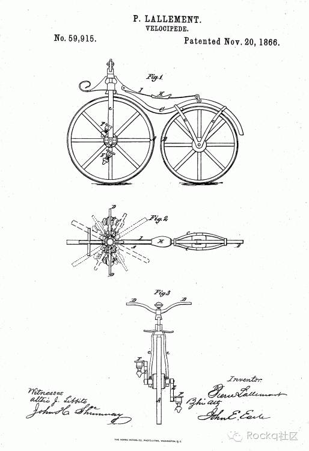

*1866年, Pierre Lallement发明了自行车*

创新也是一个寻找秘密的过程，在自然界或者人类自身上寻找，因为太阳底下 从来都没有新事物，我们所说的创新，都是将已经存在的东西进行整合罢了。大多数人不会去寻找这些秘密，有的人甚至不相信秘密，事实是还有很多秘密等待我们去探索，只有坚持不懈的探索者才能发现它们，这些人能发现尽在眼前却不为常人所见的商机。

# 总结

工作并不是全部，怎么在有限的时间里将快乐最大化，去做自己喜欢的事情是非常重要的，Facebook用它特殊的方式帮助很多人实现了这样的梦想。我们并不比作者幸运加入这样一家伟大的公司，但是我们可以在自己的公司里去尝试这些“最佳实践”，尤其是互联网公司，科技公司，有着远大目标的公司。

或者，跳槽去Facebook吧！

[figure not shown]